# DATA 202 - Analyzing Multiple Variables

FirstName LastName

There are multiple options when conducting the analysis of multiple variables (i.e., more than two variables). In this file, I provide some very basic code to help you get started on your analysis for your paper on analyzing the relationship between multiple variables.

# Libraries and packages

Load the libraries we needed. Be sure to `install.packages()` where needed.

```r
# again, remember to install necessary packages first
# install.packages("mvnormtest)

# load libraries
library(ggplot2)
library(dplyr)
library(corrplot)
library(car)
library(lmtest)
library(mvnormtest)
library(ggpubr)  # combined plots
library(vcd)     # mosaic plots
```

## Load sample data from github

We’ll use the gender pay gap data again that I have prepared.

```r
pay_gap_data <- read.csv("https://raw.githubusercontent.com/data-202/sp25/refs/heads/master/data/pay_data.csv")
```

# Exploratory analysis

```r
# view the structure of your data
str(pay_gap_data)
```

```
## 'data.frame':    100 obs. of  4 variables:
##  $ gender          : chr  "Male" "Female" "Male" "Female" ...
##  $ job_title       : chr  "Data Scientist" "Chemist" "Data Scientist" "Data Scientist" ...
##  $ years_experience: num  19 3.4 9.9 5.6 1.4 9.9 1.6 5.6 1.4 16.8 ...
##  $ annual_salary   : num  90000 45000 70000 46000 42000 84000 56000 44000 41000 74000 ...
```

```r
# view the top and bottom of your data
head(pay_gap_data)
```

```
##       gender      job_title years_experience annual_salary
## 1       Male Data Scientist             19.0         90000
## 2     Female        Chemist              3.4         45000
## 3       Male Data Scientist              9.9         70000
## 4     Female Data Scientist              5.6         46000
## 5 Non-binary      Biologist              1.4         42000
## 6       Male        Chemist              9.9         84000
```

```r
tail(pay_gap_data)
```

```
##     gender         job_title years_experience annual_salary
## 95    Male Software Engineer             13.3         78000
## 96    Male             Other             24.1        100000
## 97  Female             Other             19.4         74000
## 98    Male         Biologist              5.2         70000
## 99    Male         Biologist              7.7         64000
## 100   Male    Data Scientist             24.3        100000
```

```r
# gather counts for your categorical data
table(pay_gap_data$gender)
```

```
##
##     Female       Male Non-binary
##         37         56          7
```

```r
table(pay_gap_data$job_title)
```

```
##
##         Biologist           Chemist    Data Scientist             Other
##                20                19                19                23
## Software Engineer
##                19
```

```r
# gather descriptive statistics for your numeric variables
pay_gap_data %>%
  select(years_experience, annual_salary) %>%
  summary()
```

```
##  years_experience annual_salary
##  Min.   : 0.20    Min.   : 38000
##  1st Qu.: 5.60    1st Qu.: 56750
##  Median :10.90    Median : 68500
##  Mean   :11.95    Mean   : 68820
##  3rd Qu.:18.93    3rd Qu.: 81000
##  Max.   :25.00    Max.   :115000
```

## Anlayzing bivariate relationships

We then want to analyze the bivariate relationship between each of the variables in our model.

### Numeric-Numeric relationships

We’ll start with a scatter plot to visualize the relationship between the numeric variables.

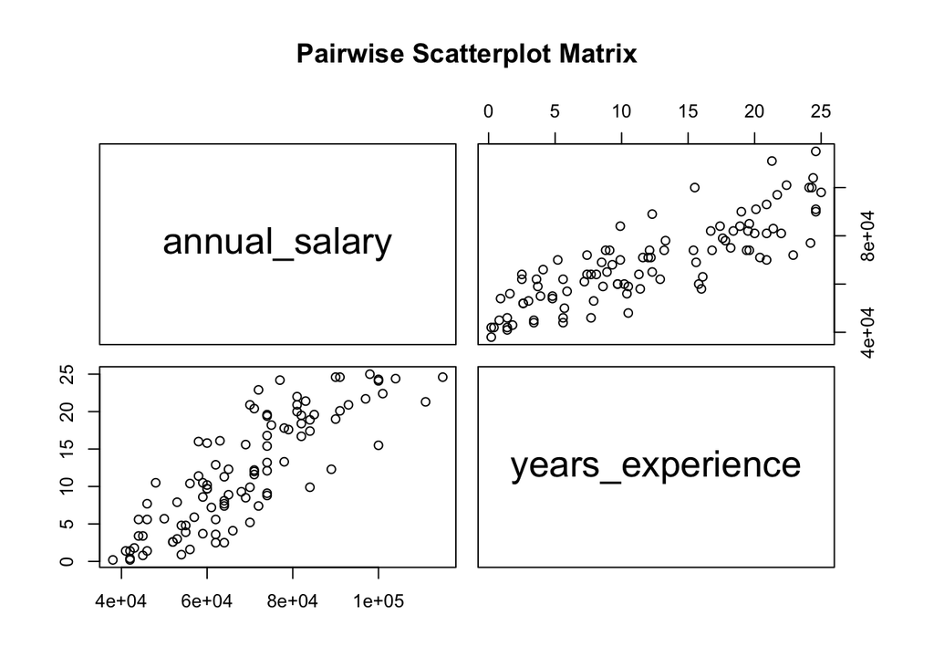

```r
pairs(pay_gap_data[, c("annual_salary", "years_experience")],
      main = "Pairwise Scatterplot Matrix")
```

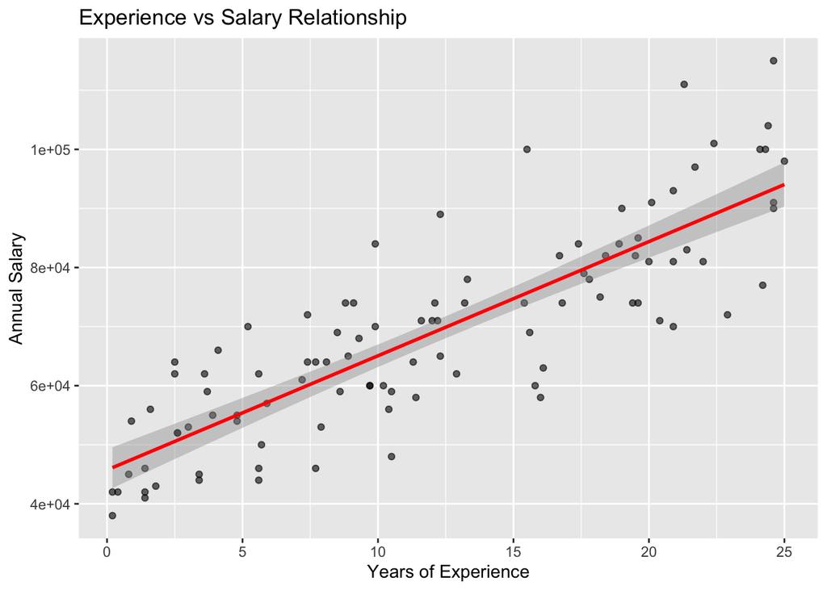

```r
ggplot(pay_gap_data, aes(x = years_experience, y = annual_salary)) +
  geom_point(alpha = 0.6) +
  geom_smooth(method = "lm", color = "red") +
  labs(title = "Experience vs Salary Relationship",
       x = "Years of Experience", y = "Annual Salary")
```

```r
# check correlation value
cor.test(pay_gap_data$annual_salary, pay_gap_data$years_experience)
```

```
##
##  Pearson's product-moment correlation
##
## data:  pay_gap_data$annual_salary and pay_gap_data$years_experience
## t = 15.413, df = 98, p-value < 2.2e-16
## alternative hypothesis: true correlation is not equal to 0
## 95 percent confidence interval:
##  0.7726828 0.8906291
## sample estimates:
##       cor
## 0.8414022
```

### Categorical-Numeric relationships

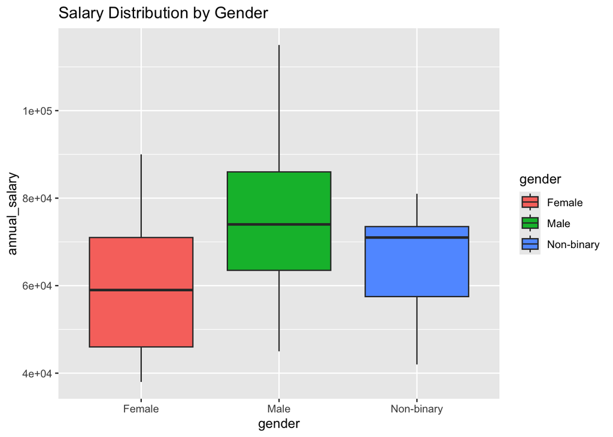

```r
## Gender vs Salary
ggplot(pay_gap_data, aes(x = gender,
                         y = annual_salary,
                         fill = gender)) +
  geom_boxplot() +
  labs(title = "Salary Distribution by Gender")
```

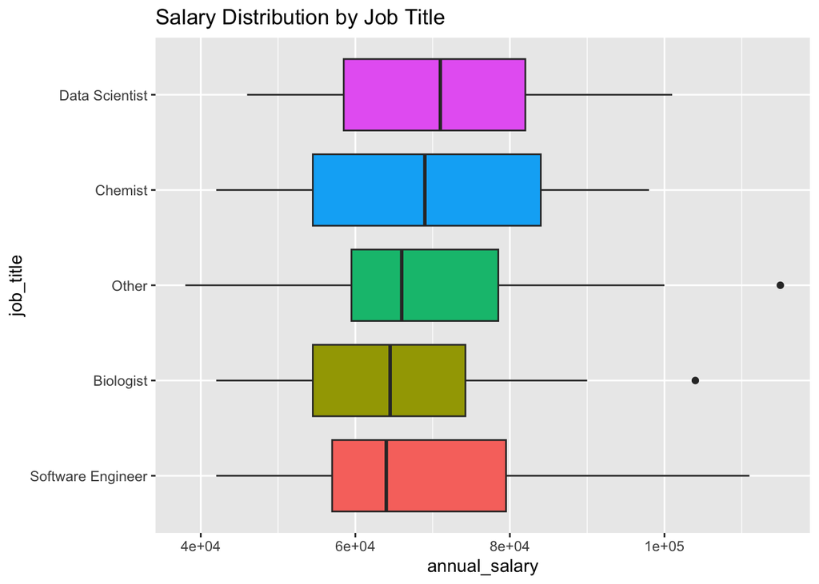

```r
## Job Title vs Salary (sorted by median salary)
pay_gap_data %>%
  mutate(job_title = reorder(job_title, annual_salary, median)) %>%
  ggplot(aes(x = job_title, y = annual_salary, fill = job_title)) +
  geom_boxplot() +
  coord_flip() +  # Better readability for long job titles
  labs(title = "Salary Distribution by Job Title") +
  theme(legend.position = "none")
```

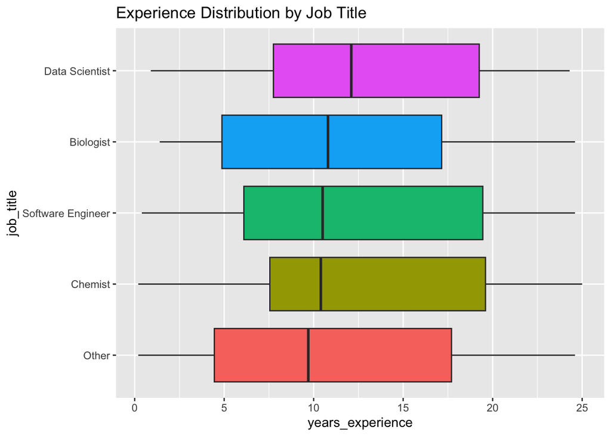

```r
## Job Title vs Experience
pay_gap_data %>%
  mutate(job_title = reorder(job_title, years_experience, median)) %>%
  ggplot(aes(x = job_title, y = years_experience, fill = job_title)) +
  geom_boxplot() +
  coord_flip() +
  labs(title = "Experience Distribution by Job Title") +
  theme(legend.position = "none")
```

### Categorical-Categorical relationship

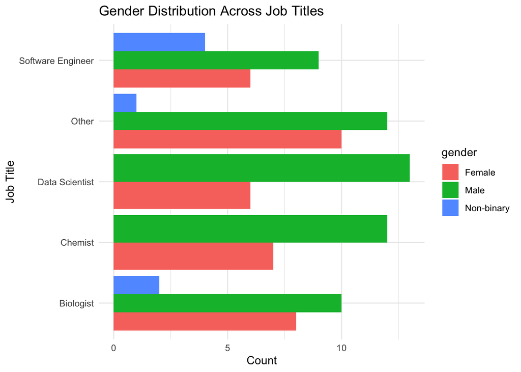

```r
# bar chart of the categorical relationships
ggplot(pay_gap_data, aes(x = job_title, fill = gender)) +
  geom_bar(position = "dodge") +
  coord_flip() +
  labs(title = "Gender Distribution Across Job Titles",
       x = "Job Title", y = "Count") +
  theme_minimal() +
  theme(axis.text.y = element_text(angle = 0, hjust = 1))
```

We can then conduct a chi-square test to see if there is a relation.

```r
## Chi-square test
chisq.test(pay_gap_data$gender, pay_gap_data$job_title)
```

```
##
##  Pearson's Chi-squared test
##
## data:  pay_gap_data$gender and pay_gap_data$job_title
## X-squared = 10.259, df = 8, p-value = 0.2473
```

## Visualizing the combined relationships

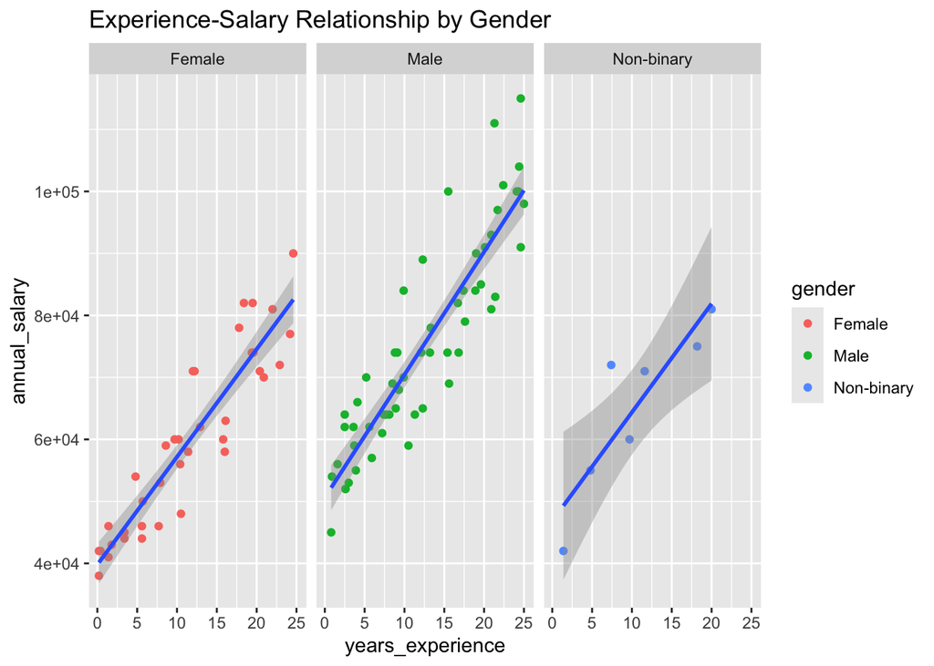

```r
## Salary ~ Experience faceted by Gender
ggplot(pay_gap_data, aes(x = years_experience, y = annual_salary)) +
  geom_point(aes(color = gender)) +
  geom_smooth(method = "lm") +
  facet_wrap(~gender) +
  labs(title = "Experience-Salary Relationship by Gender")
```

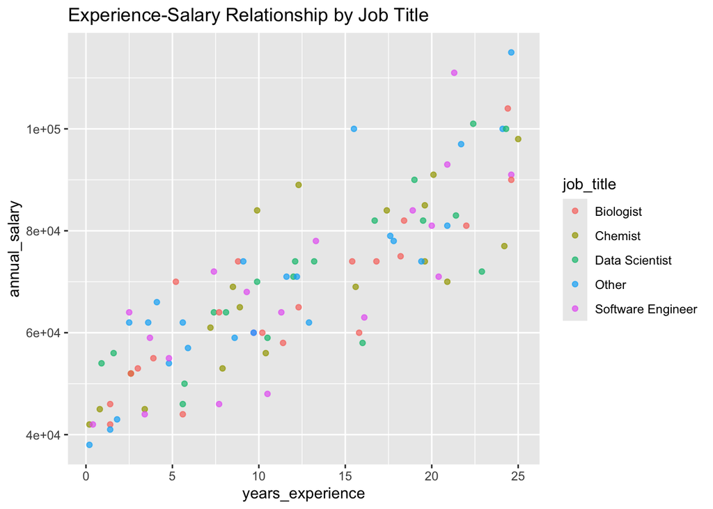

```r
## Salary ~ Experience colored by Job Title
ggplot(pay_gap_data, aes(x = years_experience, y = annual_salary, color = job_title)) +
  geom_point(alpha = 0.7) +
  labs(title = "Experience-Salary Relationship by Job Title")
```

# Multiple Variable Analysis

Multiple variable analysis is a statistical technique that examines relationships between three or more variables simultaneously. The multiple variable analysis technique involves analyzing how multiple independent variables relate to one or more dependent variables, aiming to understand the interdependence of these variables and their impact on each other.

## Research questions

RQ1: Does gender, job title, and years of experience significantly impact an individual’s annual salary?

RQ2: How much variance in salary can be explained by gender and job title after controlling for years of experience?

[interactive chart not shown]

## Base statistical models

Below, I provide the base statistical models to answer the listed research questions. However, be reminded that you should utilize your theoretical framework to drive your analysis. The most important component of our modeling here are the post-hoc tests of our assumptions.

### Research Question 1

RQ1: Does gender, job title, and years of experience significantly impact an individual’s annual salary?

```r
# Fit the model
model <- lm(annual_salary ~ gender + job_title + years_experience, data = pay_gap_data)

# Get the summary of the model
summary(model)
```

```
##
## Call:
## lm(formula = annual_salary ~ gender + job_title + years_experience,
##     data = pay_gap_data)
##
## Residuals:
##    Min     1Q Median     3Q    Max
## -13703  -3632   -128   2751  19370
##
## Coefficients:
##                            Estimate Std. Error t value Pr(>|t|)
## (Intercept)                36711.50    1968.85  18.646  < 2e-16 ***
## genderMale                 13964.08    1411.79   9.891 3.87e-16 ***
## genderNon-binary            7665.83    2841.64   2.698  0.00831 **
## job_titleChemist              -5.78    2140.76  -0.003  0.99785
## job_titleData Scientist      -47.80    2148.50  -0.022  0.98230
## job_titleOther              4453.30    2029.46   2.194  0.03073 *
## job_titleSoftware Engineer   622.90    2142.47   0.291  0.77191
## years_experience            1893.49      89.47  21.165  < 2e-16 ***
## ---
## Signif. codes:  0 '***' 0.001 '**' 0.01 '*' 0.05 '.' 0.1 ' ' 1
##
## Residual standard error: 6617 on 92 degrees of freedom
## Multiple R-squared:  0.8623, Adjusted R-squared:  0.8519
## F-statistic: 82.33 on 7 and 92 DF,  p-value: < 2.2e-16
```

#### Checking Assumptions

We then want to check the assumptions for our multiple linear regression model.

We use the `which` command here to call for specific results.

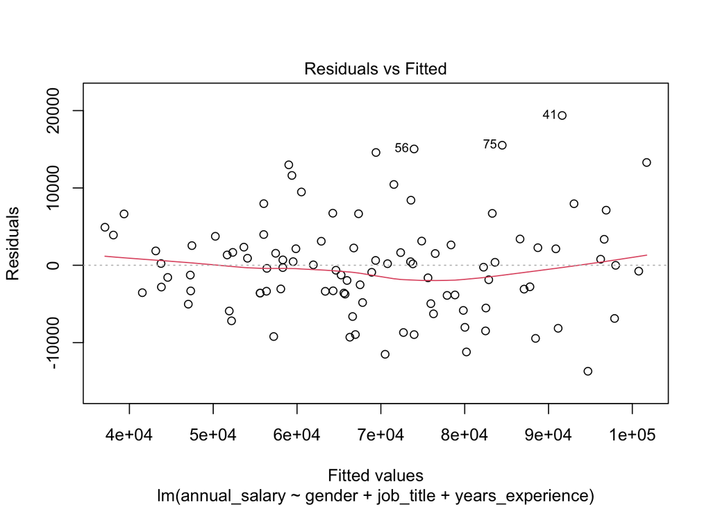

```r
# Linearity and homoscedasticity
plot(model, which = 1)
```

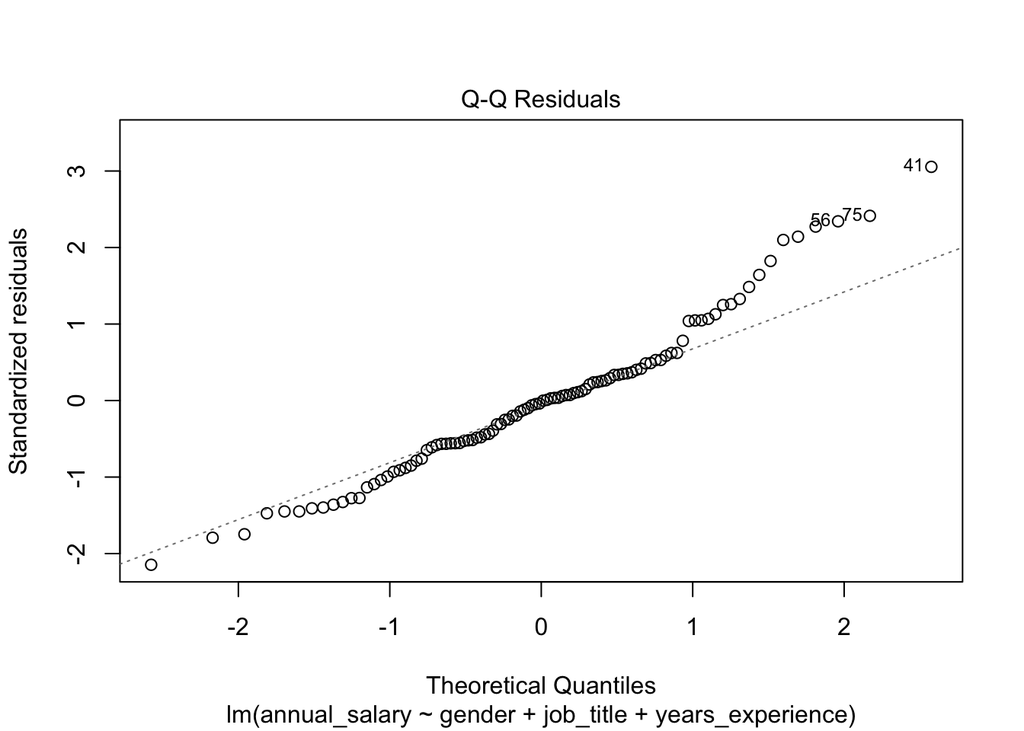

```r
# Normality of residuals
plot(model, which = 2)
```

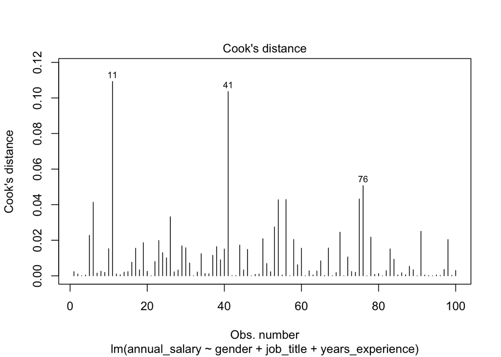

```r
# Influential points
plot(model, which = 4)
```

```r
# Multicollinearity
vif(model)
```

```
##                      GVIF Df GVIF^(1/(2*Df))
## gender           1.118704  2        1.028440
## job_title        1.121275  4        1.014411
## years_experience 1.014016  1        1.006983
```

```r
# Heteroscedasticity test
bptest(model)
```

```
##
##  studentized Breusch-Pagan test
##
## data:  model
## BP = 8.3223, df = 7, p-value = 0.305
```

### Research Question 2

RQ2: How much variance in salary can be explained by gender and job title after controlling for years of experience?

```r
# Extract R-squared values
r_squared_full <- model$r.squared

r_squared_experience <-
  summary(lm(annual_salary ~ years_experience,
             data = pay_gap_data))$r.squared

# Calculate the additional variance explained
variance.model <- r_squared_full - r_squared_experience
variance.model
```

[output not shown]

### Additional tests to examine differences by groupings

```r
## ANOVA: Job Title vs Salary
summary(aov(annual_salary ~ job_title, data = pay_gap_data))
```

```
##             Df    Sum Sq   Mean Sq F value Pr(>F)
## job_title    4 2.704e+08  67594834   0.221  0.926
## Residuals   95 2.900e+10 305225060
```

```r
## Kruskal-Wallis test (a non-parametric alternative)
kruskal.test(annual_salary ~ job_title, data = pay_gap_data)
```

```
##
##  Kruskal-Wallis rank sum test
##
## data:  annual_salary by job_title
## Kruskal-Wallis chi-squared = 0.87467, df = 4, p-value = 0.9282
```

```r
## ANOVA for Gender Differences (3 groups)
# For normally distributed data
gender_salary_aov <- aov(annual_salary ~ gender, data = pay_gap_data)
summary(gender_salary_aov)
```

```
##             Df    Sum Sq   Mean Sq F value   Pr(>F)
## gender       2 5.462e+09 2.731e+09   11.13 4.46e-05 ***
## Residuals   97 2.380e+10 2.454e+08
## ---
## Signif. codes:  0 '***' 0.001 '**' 0.01 '*' 0.05 '.' 0.1 ' ' 1
```

```r
gender_experience_aov <- aov(years_experience ~ gender, data = pay_gap_data)
summary(gender_experience_aov)
```

```
##             Df Sum Sq Mean Sq F value Pr(>F)
## gender       2     37   18.58   0.327  0.722
## Residuals   97   5511   56.81
```

```r
## Post-hoc pairwise comparisons (if ANOVA is significant)
# Tukey's Honest Significant Differences
TukeyHSD(gender_salary_aov)
```

```
##   Tukey multiple comparisons of means
##     95% family-wise confidence level
##
## Fit: aov(formula = annual_salary ~ gender, data = pay_gap_data)
##
## $gender
##                       diff        lwr       upr     p adj
## Male-Female        15511.1   7611.431 23410.770 0.0000283
## Non-binary-Female   5386.1  -9982.659 20754.859 0.6827936
## Non-binary-Male   -10125.0 -25073.224  4823.224 0.2453817
```

```r
TukeyHSD(gender_experience_aov)
```

```
##   Tukey multiple comparisons of means
##     95% family-wise confidence level
##
## Fit: aov(formula = years_experience ~ gender, data = pay_gap_data)
##
## $gender
##                         diff       lwr      upr     p adj
## Male-Female        0.9510135 -2.849798 4.751825 0.8228241
## Non-binary-Female -1.0436293 -8.438085 6.350827 0.9397284
## Non-binary-Male   -1.9946429 -9.186764 5.197479 0.7870735
```

```r
## Non-parametric alternative (Kruskal-Wallis)
kruskal.test(annual_salary ~ gender, data = pay_gap_data)
```

```
##
##  Kruskal-Wallis rank sum test
##
## data:  annual_salary by gender
## Kruskal-Wallis chi-squared = 17.035, df = 2, p-value = 2e-04
```

```r
kruskal.test(years_experience ~ gender, data = pay_gap_data)
```

```
##
##  Kruskal-Wallis rank sum test
##
## data:  years_experience by gender
## Kruskal-Wallis chi-squared = 0.69574, df = 2, p-value = 0.7062
```

```r
## Pairwise Wilcoxon Rank Sum tests with Bonferroni correction
pairwise.wilcox.test(pay_gap_data$annual_salary, pay_gap_data$gender,
                     p.adjust.method = "bonferroni")
```

```
##
##  Pairwise comparisons using Wilcoxon rank sum test with continuity correction
##
## data:  pay_gap_data$annual_salary and pay_gap_data$gender
##
##            Female  Male
## Male       0.00013 -
## Non-binary 1.00000 0.62443
##
## P value adjustment method: bonferroni
```

```r
pairwise.wilcox.test(pay_gap_data$years_experience, pay_gap_data$gender,
                     p.adjust.method = "bonferroni")
```

```
##
##  Pairwise comparisons using Wilcoxon rank sum test with continuity correction
##
## data:  pay_gap_data$years_experience and pay_gap_data$gender
##
##            Female Male
## Male       1      -
## Non-binary 1      1
##
## P value adjustment method: bonferroni
```

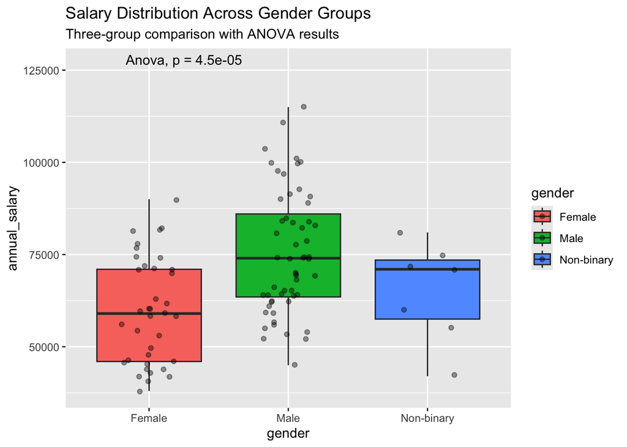

```r
## Enhanced gender-salary plot
ggplot(pay_gap_data, aes(x = gender, y = annual_salary, fill = gender)) +
  geom_boxplot() +
  geom_jitter(width = 0.2, alpha = 0.4) +
  stat_compare_means(method = "anova", label.y = max(pay_gap_data$annual_salary)*1.1) +
  labs(title = "Salary Distribution Across Gender Groups",
       subtitle = "Three-group comparison with ANOVA results")
```

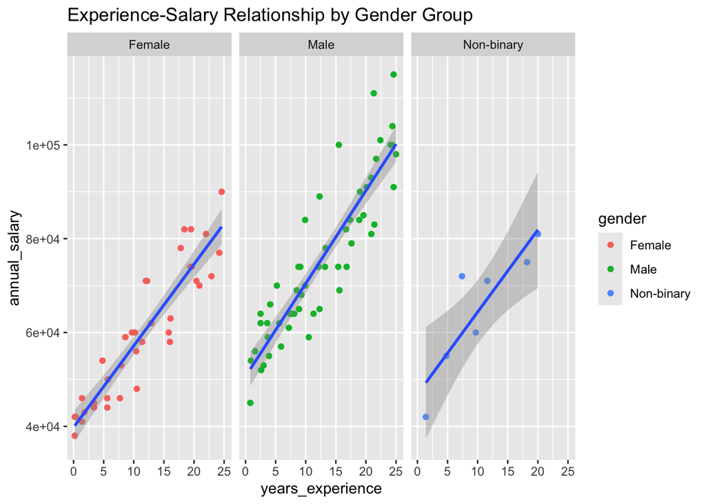

```r
## Faceted experience-salary relationship
ggplot(pay_gap_data, aes(x = years_experience, y = annual_salary)) +
  geom_point(aes(color = gender)) +
  geom_smooth(method = "lm") +
  facet_wrap(~gender, ncol = 3) +
  labs(title = "Experience-Salary Relationship by Gender Group")
```

# Multivariate Analysis

Multivariate analysis and multiple variable analysis are often confused, but they have a key distinction. Multivariate analysis specifically examines multiple dependent or outcome variables simultaneously, while multiple variable analysis (also called multivariable analysis) focuses on a single outcome variable with multiple independent variables.

## Research question

RQ1: Do gender and job title jointly influence both salary and years of experience?

RQ2: Are there significant differences in salary distributions across job titles when accounting for gender and experience?

[interactive chart not shown]

### MANOVA

RQ1: Do gender and job title jointly influence both salary and years of experience?

To answer RQ1, we’ll first run a multiple analysis of variance (MANOVA) on our data.

```r
manova_result <- manova(cbind(annual_salary, years_experience) ~ gender + job_title, data = pay_gap_data)

summary(manova_result)
```

```
##           Df  Pillai approx F num Df den Df    Pr(>F)
## gender     2 0.51380  16.0756      4    186 2.532e-11 ***
## job_title  4 0.08312   1.0082      8    186    0.4313
## Residuals 93
## ---
## Signif. codes:  0 '***' 0.001 '**' 0.01 '*' 0.05 '.' 0.1 ' ' 1
```

```r
# Perform univariate ANOVAs for each dependent variable
summary.aov(manova_result)
```

```
##  Response annual_salary :
##             Df     Sum Sq    Mean Sq F value   Pr(>F)
## gender       2 5.4621e+09 2731054952  10.742 6.35e-05 ***
## job_title    4 1.6067e+08   40167715   0.158   0.9589
## Residuals   93 2.3644e+10  254236336
## ---
## Signif. codes:  0 '***' 0.001 '**' 0.01 '*' 0.05 '.' 0.1 ' ' 1
##
##  Response years_experience :
##             Df Sum Sq Mean Sq F value Pr(>F)
## gender       2   37.2  18.578  0.3158 0.7300
## job_title    4   39.5   9.881  0.1680 0.9542
## Residuals   93 5471.0  58.828
```

```r
# Post-hoc tests for job title (if significant)
TukeyHSD(aov(annual_salary ~ job_title, data = pay_gap_data))
```

```
##   Tukey multiple comparisons of means
##     95% family-wise confidence level
##
## Fit: aov(formula = annual_salary ~ job_title, data = pay_gap_data)
##
## $job_title
##                                        diff       lwr      upr     p adj
## Chemist-Biologist                 2744.7368 -12819.59 18309.07 0.9880828
## Data Scientist-Biologist          4902.6316 -10661.70 20466.96 0.9050536
## Other-Biologist                   3676.0870 -11177.98 18530.15 0.9585863
## Software Engineer-Biologist       1955.2632 -13609.07 17519.59 0.9967520
## Data Scientist-Chemist            2157.8947 -13604.72 17920.50 0.9954695
## Other-Chemist                      931.3501 -14130.35 15993.05 0.9998006
## Software Engineer-Chemist         -789.4737 -16552.08 14973.14 0.9999138
## Other-Data Scientist             -1226.5446 -16288.24 13835.15 0.9994066
## Software Engineer-Data Scientist -2947.3684 -18709.98 12815.24 0.9851493
## Software Engineer-Other          -1720.8238 -16782.52 13340.87 0.9977552
```

```r
TukeyHSD(aov(years_experience ~ job_title, data = pay_gap_data))
```

```
##   Tukey multiple comparisons of means
##     95% family-wise confidence level
##
## Fit: aov(formula = years_experience ~ job_title, data = pay_gap_data)
##
## $job_title
##                                        diff       lwr      upr     p adj
## Chemist-Biologist                 0.8871053 -5.890221 7.664432 0.9961911
## Data Scientist-Biologist          1.6607895 -5.116537 8.438116 0.9600164
## Other-Biologist                  -0.3419565 -6.810004 6.126091 0.9998930
## Software Engineer-Biologist       0.4502632 -6.327063 7.227590 0.9997349
## Data Scientist-Chemist            0.7736842 -6.089981 7.637350 0.9978703
## Other-Chemist                    -1.2290618 -7.787521 5.329398 0.9850252
## Software Engineer-Chemist        -0.4368421 -7.300507 6.426823 0.9997764
## Other-Data Scientist             -2.0027460 -8.561205 4.555713 0.9143543
## Software Engineer-Data Scientist -1.2105263 -8.074192 5.653139 0.9880778
## Software Engineer-Other           0.7922197 -5.766240 7.350679 0.9972112
```

#### Check MANOVA assumptions

```r
# Multivariate normality
mshapiro.test(t(model.matrix(manova_result)[, -1]))
```

```
##
##  Shapiro-Wilk normality test
##
## data:  Z
## W = 0.74976, p-value = 9.227e-12
```

```r
# Homogeneity of covariance matrices
leveneTest(annual_salary ~ gender * job_title, data = pay_gap_data)
```

```
## Levene's Test for Homogeneity of Variance (center = median)
##       Df F value Pr(>F)
## group 12   0.597 0.8391
##       87
```

```r
leveneTest(years_experience ~ gender * job_title, data = pay_gap_data)
```

```
## Levene's Test for Homogeneity of Variance (center = median)
##       Df F value Pr(>F)
## group 12  0.6305 0.8108
##       87
```

### Visual of the results

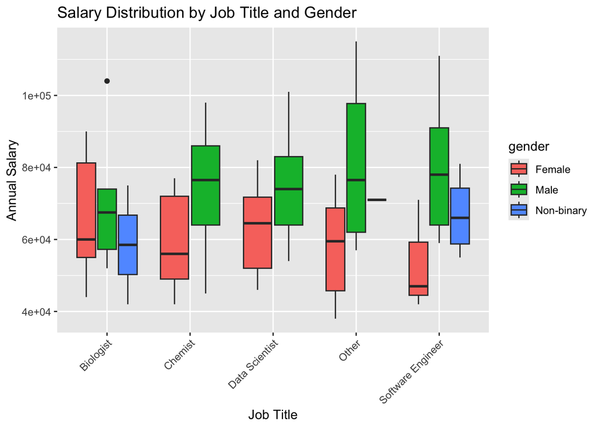

```r
ggplot(pay_gap_data, aes(x = job_title, y = annual_salary, fill = gender)) +
  geom_boxplot() +
  theme(axis.text.x = element_text(angle = 45, hjust = 1)) +
  labs(title = "Salary Distribution by Job Title and Gender",
       x = "Job Title", y = "Annual Salary")
```

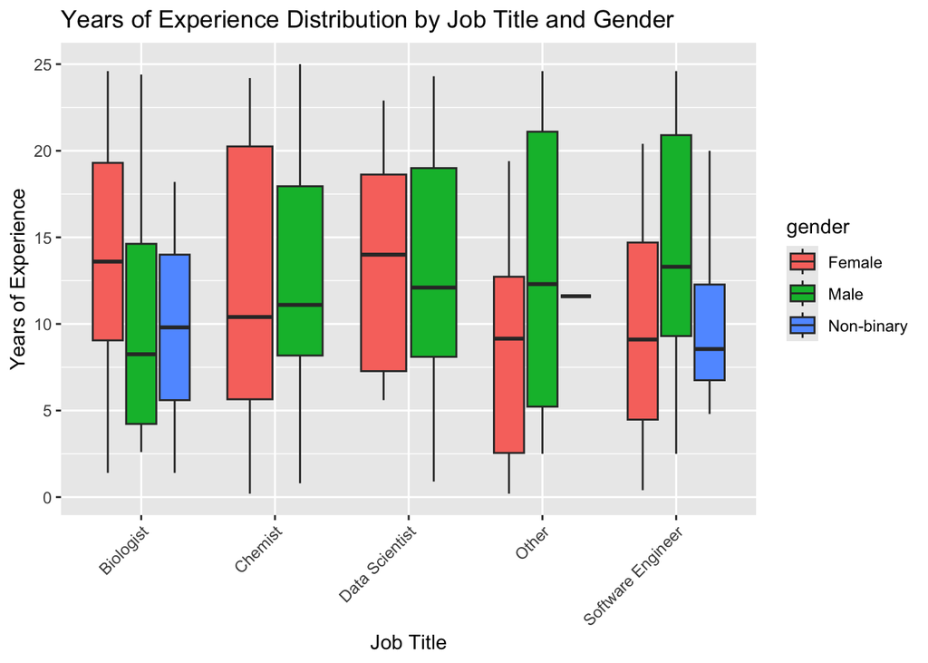

```r
ggplot(pay_gap_data, aes(x = job_title, y = years_experience, fill = gender)) +
  geom_boxplot() +
  theme(axis.text.x = element_text(angle = 45, hjust = 1)) +
  labs(title = "Years of Experience Distribution by Job Title and Gender",
       x = "Job Title", y = "Years of Experience")
```

RQ2: Are there significant differences in salary distributions across job titles when accounting for gender and experience?

To answer research question two, we’ll run some additoinal analyses.

```r
model_salary <- lm(annual_salary ~ job_title + gender + years_experience, data = pay_gap_data)
anova(model_salary)
```

```
## Analysis of Variance Table
##
## Response: annual_salary
##                  Df     Sum Sq    Mean Sq  F value Pr(>F)
## job_title         4 2.7038e+08 6.7595e+07   1.5436 0.1962
## gender            2 5.3524e+09 2.6762e+09  61.1142 <2e-16 ***
## years_experience  1 1.9615e+10 1.9615e+10 447.9384 <2e-16 ***
## Residuals        92 4.0287e+09 4.3790e+07
## ---
## Signif. codes:  0 '***' 0.001 '**' 0.01 '*' 0.05 '.' 0.1 ' ' 1
```

```r
summary(model_salary)
```

```
##
## Call:
## lm(formula = annual_salary ~ job_title + gender + years_experience,
##     data = pay_gap_data)
##
## Residuals:
##    Min     1Q Median     3Q    Max
## -13703  -3632   -128   2751  19370
##
## Coefficients:
##                            Estimate Std. Error t value Pr(>|t|)
## (Intercept)                36711.50    1968.85  18.646  < 2e-16 ***
## job_titleChemist              -5.78    2140.76  -0.003  0.99785
## job_titleData Scientist      -47.80    2148.50  -0.022  0.98230
## job_titleOther              4453.30    2029.46   2.194  0.03073 *
## job_titleSoftware Engineer   622.90    2142.47   0.291  0.77191
## genderMale                 13964.08    1411.79   9.891 3.87e-16 ***
## genderNon-binary            7665.83    2841.64   2.698  0.00831 **
## years_experience            1893.49      89.47  21.165  < 2e-16 ***
## ---
## Signif. codes:  0 '***' 0.001 '**' 0.01 '*' 0.05 '.' 0.1 ' ' 1
##
## Residual standard error: 6617 on 92 degrees of freedom
## Multiple R-squared:  0.8623, Adjusted R-squared:  0.8519
## F-statistic: 82.33 on 7 and 92 DF,  p-value: < 2.2e-16
```

As noted in class, these are base models to help you consider your analysis. However, your theory should lead all of your work. Please let me know if you have any questions.